# Week 9 - Homework

Author

David Gonzalez Chavez

# Data

The data for this homework assignment comes from the 2022 GSS.

```r
gss2022 <- gss_get_yr(year = 2022) |> # get 2022 GSS data
  haven::zap_labels()                 # remove labels
```

# Analysis #1: Degree Attainment by Sex

The first analysis will be between men and women. The analysis will be differences in their Graduate degree attainment.

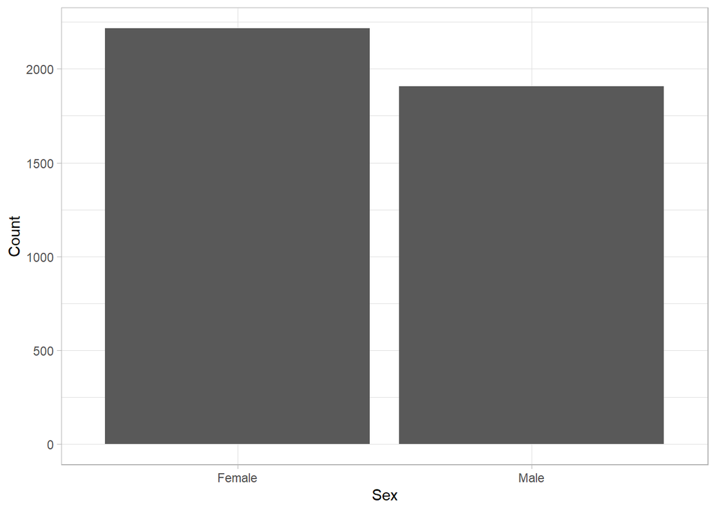

```r
sex_degree_all <- gss2022 |>
  select(sex, degree) |> # select the sex variable and degree (comparison) variables
  drop_na() |>
  mutate(sex_label = if_else(sex == 1, "Male", "Female")) |>
  mutate(sex = if_else(sex == 1, 1, 0)) |>
  mutate(grad_label = if_else(degree==4, "Graduate Degree", "No Graduate Degree")) |>
  mutate(grad = if_else(degree == 4, 1, 0)) # if degree is 4, they have graduate degree


ggplot(sex_degree_all,
       aes(x = sex_label)) +
  geom_bar() +
  xlab("Sex") +
  ylab("Count")
```

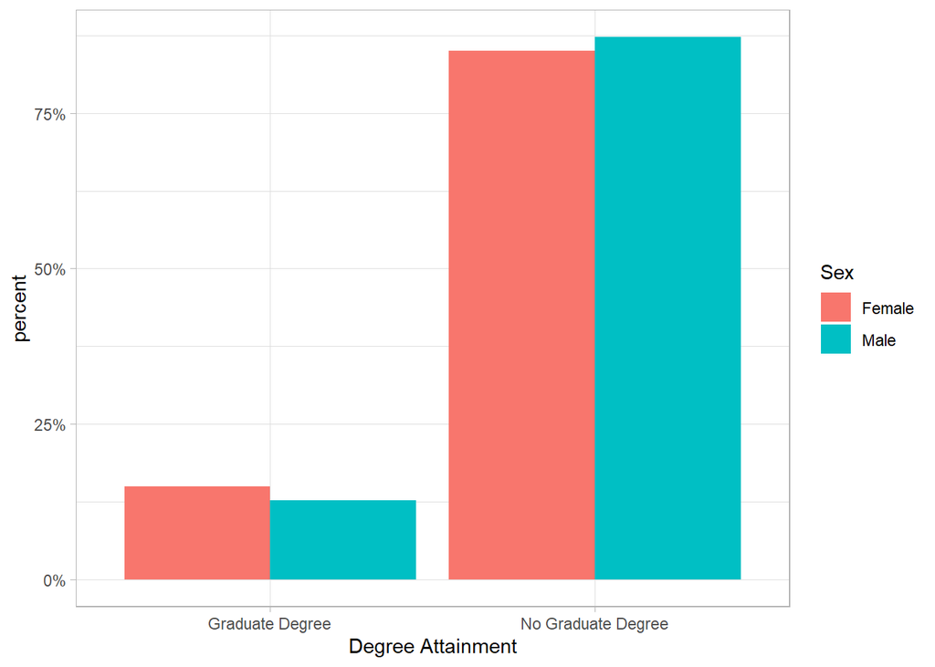

```r
sex_degree_plot <- sex_degree_all |>
  group_by(sex_label, grad_label) |> # group by sex and degree status
  summarize(n = n()) |> # get count with that combo
  mutate(percent = n/sum(n)) # get percent of group for each subgroup

ggplot(sex_degree_plot,
       aes(x = grad_label,
           fill = sex_label,
           y = percent)) +
  geom_bar(position = "dodge",
           stat = "identity") +
  labs(x = "Degree Attainment",
       fill = "Sex") +
  scale_y_continuous(labels = scales::percent)
```

## Difference in Probability Regression

```r
mod1_sex_degree <- glm(grad ~ sex,
            data = sex_degree_all,
            family = binomial(link = "identity"))

summary(mod1_sex_degree)
```

```
Call:
glm(formula = grad ~ sex, family = binomial(link = "identity"),
    data = sex_degree_all)

Coefficients:
             Estimate Std. Error z value Pr(>|z|)
(Intercept)  0.149819   0.007581  19.761   <2e-16 ***
sex         -0.021937   0.010767  -2.037   0.0416 *
---
Signif. codes:  0 '***' 0.001 '**' 0.01 '*' 0.05 '.' 0.1 ' ' 1

(Dispersion parameter for binomial family taken to be 1)

    Null deviance: 3335.2  on 4123  degrees of freedom
Residual deviance: 3331.1  on 4122  degrees of freedom
AIC: 3335.1

Number of Fisher Scoring iterations: 2
```

The difference in probabilities regression suggests that men are 2.19 percentage points less likely to have a graduate degree than women. The p-value for this estimate is less than our alpha level of .05, therefore we can reject the null hypothesis (no difference in probability).

## Risk Ratio Regression

```r
mod2_sex_degree <- glm(grad ~ sex,
            data = sex_degree_all,
            family = binomial(link = "log"))

summary(mod2_sex_degree)
```

```
Call:
glm(formula = grad ~ sex, family = binomial(link = "log"), data = sex_degree_all)

Coefficients:
            Estimate Std. Error z value Pr(>|z|)
(Intercept) -1.89832    0.05060 -37.513   <2e-16 ***
sex         -0.15832    0.07833  -2.021   0.0433 *
---
Signif. codes:  0 '***' 0.001 '**' 0.01 '*' 0.05 '.' 0.1 ' ' 1

(Dispersion parameter for binomial family taken to be 1)

    Null deviance: 3335.2  on 4123  degrees of freedom
Residual deviance: 3331.1  on 4122  degrees of freedom
AIC: 3335.1

Number of Fisher Scoring iterations: 6
```

```r
exp(summary(mod2_sex_degree)$coefficients[2])
```

```
[1] 0.8535778
```

The risk ratio regression suggests that men are 85.3577833 percent as likely to have a graduate degree than women. The p-value for this estimate is less than our alpha level of .05, therefore we can reject the null hypothesis (no difference in risk).

## Confidence Intervals

```r
sex_degree_m <- sex_degree_all |>
  filter(sex == 1)

sex_degree_f <- sex_degree_all |>
  filter(sex == 0)

mean_sex_degree_m <- mean(sex_degree_m$grad)
mean_sex_degree_f <- mean(sex_degree_f$grad)

sd_sex_degree_m <- sd(sex_degree_m$grad)
sd_sex_degree_f <- sd(sex_degree_f$grad)

n_sex_degree_m <- nrow(sex_degree_m)
n_sex_degree_f <- nrow(sex_degree_f)

diff_sex_degree <- mean_sex_degree_m - mean_sex_degree_f
sediff_sex_degree <- sqrt((sd_sex_degree_m ^ 2/ n_sex_degree_m) + (sd_sex_degree_f ^ 2 / n_sex_degree_f))

lower_sex_degree <- diff_sex_degree - qnorm(1 - (.05 / 2)) * sediff_sex_degree # get lower bound using 95% confidence
upper_sex_degree <- diff_sex_degree + qnorm(1 - (.05 / 2)) * sediff_sex_degree # get higher bound using 95% confidence
```

A 95% confidence interval for this comparison would be would be between -0.043 and -8^{-4}. Because 0 is not in this range, we can reject the null hypothesis that there is no difference in mean graduate degree attainment between men and women.

# Analysis #2: 2020 Election by Sex

The second analysis will also be between men and women. The analysis will be differences in whether they voted for Biden in 2020.

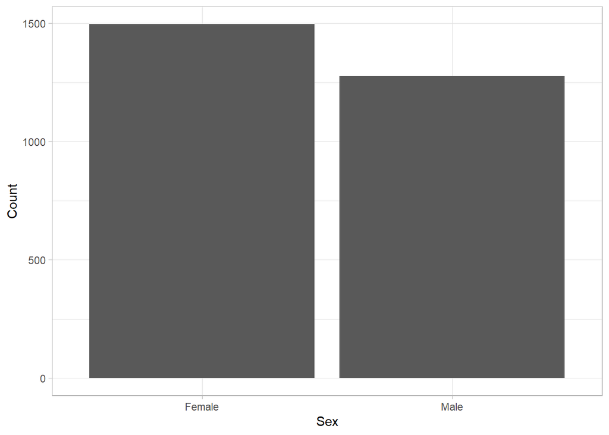

```r
sex_biden_all <- gss2022 |>
  select(sex, pres20) |> # pick sex and the pres20 question asking who they voted for in 2020 election
  drop_na() |>  #get rid of n/a values
  mutate(sex_label = if_else(sex == 1, "Male", "Female")) |>
  mutate(sex = if_else(sex == 1, 1, 0)) |>
  filter(pres20 != 4) |>  # removing people who did not vote; only interested in people who impacted election
  mutate(vote = if_else(pres20 == 1, 1, 0)) |>  # make it binary: voted for biden or not
  mutate(vote_label = if_else(pres20 == 1, "Biden", "Not Biden"))

ggplot(sex_biden_all,
       aes(x = sex_label)) +
  geom_bar() +
  xlab("Sex") +
  ylab("Count")
```

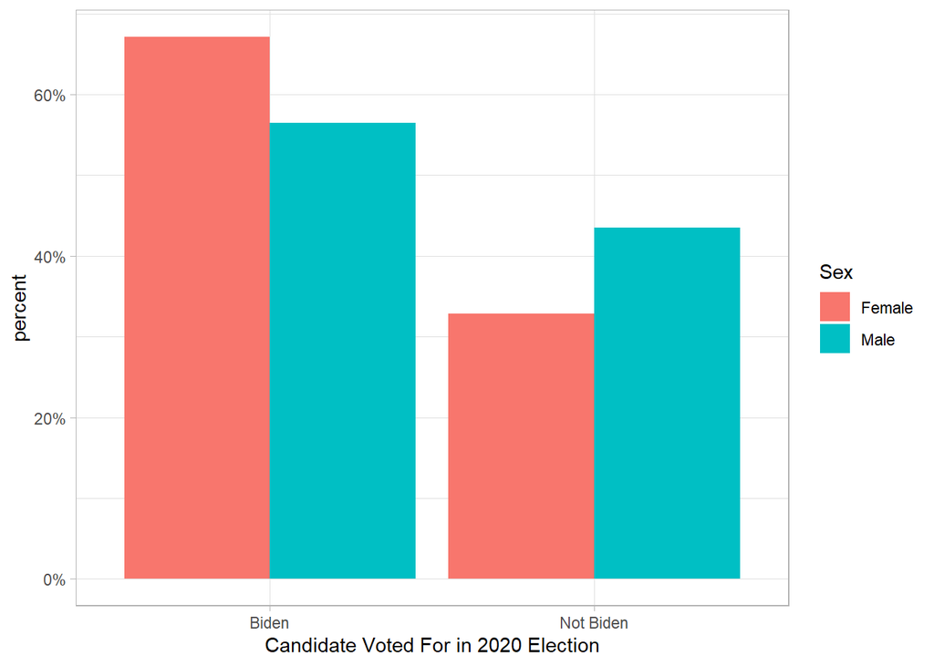

```r
sex_biden_plot <- sex_biden_all |>
  group_by(sex_label, vote_label) |> # group by sex and degree status
  summarize(n = n()) |> # get count with that combo
  mutate(percent = n/sum(n)) # get percent of group for each subgroup

ggplot(sex_biden_plot,
       aes(x = vote_label,
           fill = sex_label,
           y = percent)) +
  geom_bar(position = "dodge",
           stat = "identity") +
  labs(x = "Candidate Voted For in 2020 Election",
       fill = "Sex") +
  scale_y_continuous(labels = scales::percent)
```

## Difference in Probability Regression

```r
mod1_sex_biden <- glm(vote ~ sex,
            data = sex_biden_all,
            family = binomial(link = "identity"))

summary(mod1_sex_biden)
```

```
Call:
glm(formula = vote ~ sex, family = binomial(link = "identity"),
    data = sex_biden_all)

Coefficients:
            Estimate Std. Error z value Pr(>|z|)
(Intercept)  0.67112    0.01215  55.252  < 2e-16 ***
sex         -0.10608    0.01844  -5.752 8.84e-09 ***
---
Signif. codes:  0 '***' 0.001 '**' 0.01 '*' 0.05 '.' 0.1 ' ' 1

(Dispersion parameter for binomial family taken to be 1)

    Null deviance: 3675.3  on 2771  degrees of freedom
Residual deviance: 3642.3  on 2770  degrees of freedom
AIC: 3646.3

Number of Fisher Scoring iterations: 2
```

The difference in probabilities regression suggests that men are 10.61 percentage points less likely to have voted for Biden than women. The p-value for this estimate is less than our alpha level of .05, therefore we can reject the null hypothesis (no difference in probability).

## Risk Ratio Regression

```r
mod2_sex_biden <- glm(vote ~ sex,
            data = sex_biden_all,
            family = binomial(link = "log"))

summary(mod2_sex_biden)
```

```
Call:
glm(formula = vote ~ sex, family = binomial(link = "log"), data = sex_biden_all)

Coefficients:
            Estimate Std. Error z value Pr(>|z|)
(Intercept) -0.39880    0.01810 -22.035  < 2e-16 ***
sex         -0.17204    0.03051  -5.639 1.71e-08 ***
---
Signif. codes:  0 '***' 0.001 '**' 0.01 '*' 0.05 '.' 0.1 ' ' 1

(Dispersion parameter for binomial family taken to be 1)

    Null deviance: 3675.3  on 2771  degrees of freedom
Residual deviance: 3642.3  on 2770  degrees of freedom
AIC: 3646.3

Number of Fisher Scoring iterations: 5
```

```r
exp(summary(mod2_sex_biden)$coefficients[2])
```

```
[1] 0.8419426
```

The risk ratio regression suggests that men are 84.19 percent as likely to have vote for Biden compared to women. The p-value for this estimate is less than our alpha level of .05, therefore we can reject the null hypothesis (no difference in risk).

## Confidence Intervals

```r
sex_biden_m <- sex_biden_all |>
  filter(sex == 1)

sex_biden_f <- sex_biden_all |>
  filter(sex == 0)

mean_sex_biden_m <- mean(sex_biden_m$vote)
mean_sex_biden_f <- mean(sex_biden_f$vote)

sd_sex_biden_m <- sd(sex_biden_m$vote)
sd_sex_biden_f <- sd(sex_biden_f$vote)

n_sex_biden_m <- nrow(sex_biden_m)
n_sex_biden_f <- nrow(sex_biden_f)

diff_sex_biden <- mean_sex_biden_m - mean_sex_biden_f
sediff_sex_biden <- sqrt((sd_sex_biden_m ^ 2/ n_sex_biden_m) + (sd_sex_biden_f ^ 2 / n_sex_biden_f))

lower_sex_biden <- diff_sex_biden - qnorm(1 - (.05 / 2)) * sediff_sex_biden # get lower bound using 95% confidence
upper_sex_biden <- diff_sex_biden + qnorm(1 - (.05 / 2)) * sediff_sex_biden # get higher bound using 95% confidence
```

A 95% confidence interval for this comparison would be would be between -0.1422 and -0.0699. Because 0 is not in this range, we can reject the null hypothesis that there is no difference in the mean percentage of votes towards Biden between men and women.